# Chapter 8 problems

#### 8H1

Run the model below and then inspect the posterior distribution and explain what it is accomplishing.

```r
library(rethinking)
library(rstan)
rstan_options(auto_write = TRUE)
options(mc.cores = parallel::detectCores())

mp <- map2stan(
  alist(
  a ~ dnorm(0,1),
  b ~ dcauchy(0,1)
),
data=list(y=1),
start=list(a=0,b=0),
iter=1e4, warmup=100 , WAIC=FALSE )
```

[output not shown]

```r
#ran slowly.  I don't see a model here, just parameters

precis(mp)
```

```
##    Mean StdDev lower 0.89 upper 0.89 n_eff Rhat
## a  0.00   1.08      -1.75       1.69  9605    1
## b -2.78  66.24      -8.49       8.16   792    1
```

```r
post.mp <- extract.samples(mp)
str(post.mp) # 2 values, as expected, but even here I can see they vary wildly.
```

```
## List of 2
##  $ a: num [1:9900(1d)] -0.975 -1.024 0.331 -1.186 -0.21 ...
##  $ b: num [1:9900(1d)] 2.777 -0.619 -17.34 1.69 3.758 ...
```

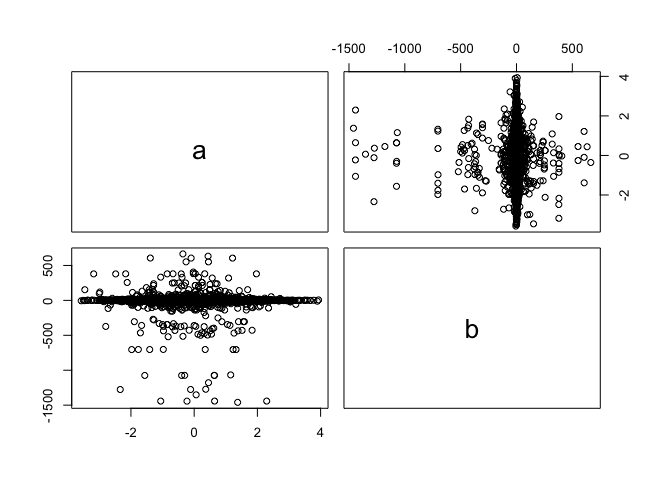

```r
pairs(post.mp) # no relationship between them, but why would there be?
```

```r
plot(mp) # messy.  poor stationarity/convergence.

summary(post.mp$a)  # looks like samples from the normal distribution
```

```
##      Min.   1st Qu.    Median      Mean   3rd Qu.      Max.
## -3.574000 -0.726300 -0.014710 -0.001615  0.732400  3.935000
```

```r
summary(post.mp$b) # much
```

```
##       Min.    1st Qu.     Median       Mean    3rd Qu.       Max.
## -1460.0000    -1.1830    -0.0191    -2.7810     1.1800   665.4000
```

[figure not shown]

I think I’m just recovering samples from the Gaussian and Cauchy distributions. Cauchy has long tails. But shouldn’t this be half Cauchy? so why negative values for b?

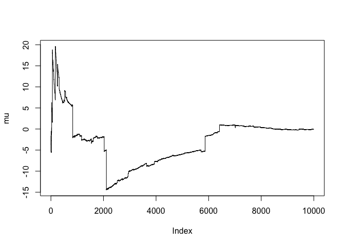

```r
y <- rcauchy(1e4,0,5)
mu <- sapply( 1:length(y) , function(i) sum(y[1:i])/i )
plot(mu,type="l")
```

#### 8H2

REvist models from chapter 5; Repeat that analysis, using map2stan this time, fitting models m5.1, m5.2, and m5.3. Use compare to compare the models on the basis of WAIC. Explain the results.

```r
library(rethinking)
library(rstan)
data(WaffleDivorce)
d <- WaffleDivorce
# standardize predictor
d$MedianAgeMarriage.s <- (d$MedianAgeMarriage-mean(d$MedianAgeMarriage))/
sd(d$MedianAgeMarriage)

# get rid of data I won't need for these models

d.trim <- d[, c(4,5,7,14)]

# fit first model
m5.1 <- map(
  alist(
    Divorce ~ dnorm( mu , sigma ) ,
    mu <- a + bA * MedianAgeMarriage.s ,
    a ~ dnorm( 10 , 10 ) ,
    bA ~ dnorm( 0 , 1 ) ,
    sigma ~ dunif( 0 , 10 )
) , data = d.trim )
precis(m5.1)
```

```
##        Mean StdDev  5.5% 94.5%
## a      9.69   0.20  9.36 10.02
## bA    -1.04   0.20 -1.37 -0.72
## sigma  1.45   0.14  1.21  1.68
```

```r
m5.1.stan <- map2stan(
  alist(
    Divorce ~ dnorm( mu , sigma ) ,
    mu <- a + bA * MedianAgeMarriage.s ,
    a ~ dnorm( 10 , 10 ) ,
    bA ~ dnorm( 0 , 1 ) ,
    sigma ~ dunif( 0 , 10 )  # I'm keepign the uniform prior, although I could have changed it to half Cauchy
) , data = d.trim )
```

[output not shown]

```
## Computing WAIC
```

```
## Constructing posterior predictions
```

```
## [ 100 / 1000 ]
[ 200 / 1000 ]
[ 300 / 1000 ]
[ 400 / 1000 ]
[ 500 / 1000 ]
[ 600 / 1000 ]
[ 700 / 1000 ]
[ 800 / 1000 ]
[ 900 / 1000 ]
[ 1000 / 1000 ]
```

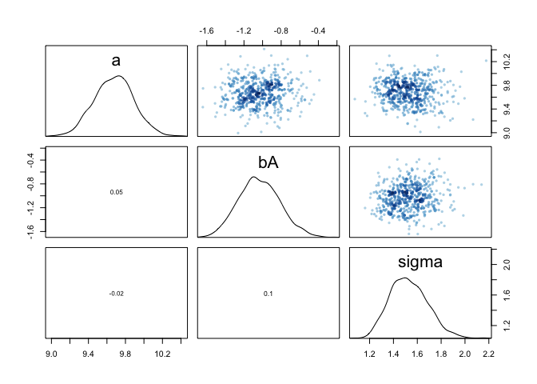

```r
pairs(m5.1.stan)
```

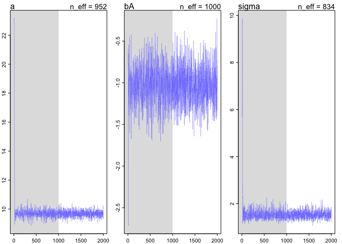

```r
plot(m5.1.stan) # seems OK
```

```r
compare(m5.1, m5.1.stan)
```

```
##            WAIC pWAIC dWAIC weight   SE  dSE
## m5.1.stan 186.3   3.8   0.0   0.61 12.3   NA
## m5.1      187.2   4.5   0.9   0.39 14.1 1.83
```

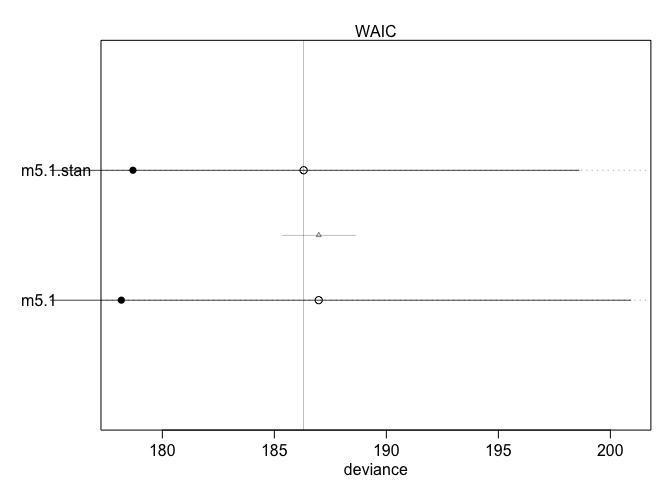

```r
# these are very similar.
par(mfrow=c(1,1))
plot( compare(m5.1, m5.1.stan) , SE=TRUE , dSE=TRUE )  # very similar
```

```r
# now the second model
d.trim$Marriage.s <- (d.trim$Marriage - mean(d.trim$Marriage))/sd(d.trim$Marriage)
m5.2 <- map(
  alist(
    Divorce ~ dnorm( mu , sigma ) ,
    mu <- a + bR * Marriage.s ,
    a ~ dnorm( 10 , 10 ) ,
    bR ~ dnorm( 0 , 1 ) ,
    sigma ~ dunif( 0 , 10 )
) , data = d.trim )

m5.2.stan <- map2stan(
  alist(
    Divorce ~ dnorm( mu , sigma ) ,
    mu <- a + bR * Marriage.s ,
    a ~ dnorm( 10 , 10 ) ,
    bR ~ dnorm( 0 , 1 ) ,
    sigma ~ dunif( 0 , 10 )
) , data = d.trim )
```

[output not shown]

```
## Computing WAIC
```

```
## Constructing posterior predictions
```

```
## [ 100 / 1000 ]
[ 200 / 1000 ]
[ 300 / 1000 ]
[ 400 / 1000 ]
[ 500 / 1000 ]
[ 600 / 1000 ]
[ 700 / 1000 ]
[ 800 / 1000 ]
[ 900 / 1000 ]
[ 1000 / 1000 ]
```

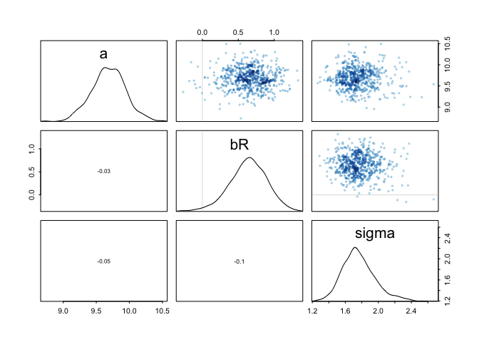

```r
pairs(m5.2.stan)
```

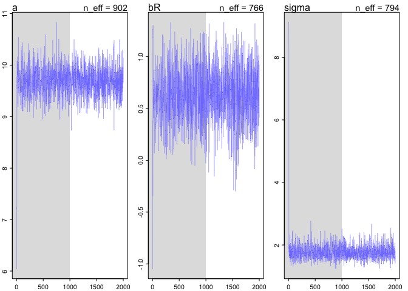

```r
plot(m5.2.stan) # seems OK
```

```r
compare(m5.2, m5.2.stan)  # again, almost identical
```

```
##            WAIC pWAIC dWAIC weight    SE  dSE
## m5.2.stan 200.6   3.5     0    0.5  9.65   NA
## m5.2      200.6   3.8     0    0.5 10.76 1.13
```

```r
plot( compare(m5.2, m5.2.stan) , SE=TRUE , dSE=TRUE )  # very similar
# last model; incorporate marriage age and marriage rate

m5.3 <- map(
  alist(
    Divorce ~ dnorm( mu , sigma ) ,
    mu <- a + bR*Marriage.s + bA*MedianAgeMarriage.s ,
    a ~ dnorm( 10 , 10 ) ,
    bR ~ dnorm( 0 , 1 ) ,
    bA ~ dnorm( 0 , 1 ) ,
    sigma ~ dunif( 0 , 10 )
) ,
data = d.trim)

m5.3.stan <- map2stan(
  alist(
    Divorce ~ dnorm( mu , sigma ) ,
    mu <- a + bR*Marriage.s + bA*MedianAgeMarriage.s ,
    a ~ dnorm( 10 , 10 ) ,
    bR ~ dnorm( 0 , 1 ) ,
    bA ~ dnorm( 0 , 1 ) ,
    sigma ~ dunif( 0 , 10 )
) ,
data = d.trim)
```

[output not shown]

```
## Computing WAIC
```

```
## Constructing posterior predictions
```

```
## [ 100 / 1000 ]
[ 200 / 1000 ]
[ 300 / 1000 ]
[ 400 / 1000 ]
[ 500 / 1000 ]
[ 600 / 1000 ]
[ 700 / 1000 ]
[ 800 / 1000 ]
[ 900 / 1000 ]
[ 1000 / 1000 ]
```

```r
precis( m5.3.stan )
```

```
##        Mean StdDev lower 0.89 upper 0.89 n_eff Rhat
## a      9.68   0.23       9.33      10.06   761    1
## bR    -0.13   0.29      -0.60       0.30   563    1
## bA    -1.14   0.29      -1.63      -0.71   544    1
## sigma  1.54   0.16       1.28       1.78   797    1
```

[figure not shown]

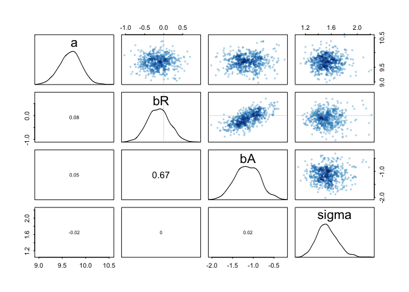

```r
pairs(m5.3.stan)  # now, correlation between bR and bA.
```

```r
plot(m5.3.stan) # seems OK
compare(m5.3, m5.3.stan)  # again, almost identical
```

```
##            WAIC pWAIC dWAIC weight    SE  dSE
## m5.3.stan 188.2   4.9   0.0    0.7 12.35   NA
## m5.3      189.8   6.1   1.7    0.3 14.85 2.55
```

[figure not shown]

```r
par(mfrow=c(1,1))
```

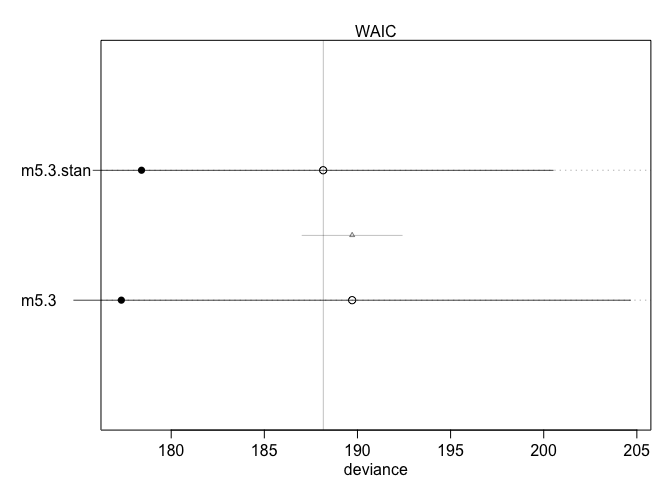

```r
plot( compare(m5.3, m5.3.stan) , SE=TRUE , dSE=TRUE )  # very similar
```

```r
## so doesn't matter in this case whether you use MCMC or not.
```

#### 8H3

Changing parameters.

```r
N <- 100 # number of individuals
height <- rnorm(N,10,2) # sim total height of each
leg_prop <- runif(N,0.4,0.5) # leg as proportion of height
leg_left <- leg_prop*height + # sim left leg as proportion + error
rnorm( N , 0 , 0.02 )
leg_right <- leg_prop*height + # sim right leg as proportion + error
rnorm( N , 0 , 0.02 )
# combine into data frame
d <- data.frame(height,leg_left,leg_right)

# fit model using stan

m5.8s <- map2stan(
  alist(
    height ~ dnorm( mu , sigma ) ,
    mu <- a + bl*leg_left + br*leg_right ,
    a ~ dnorm( 10 , 100 ) ,
    bl ~ dnorm( 2 , 10 ) ,
    br ~ dnorm( 2 , 10 ) ,
    sigma ~ dcauchy( 0 , 1 )
) ,
data=d, chains=4,
start=list(a=10,bl=0,br=0,sigma=1) )
```

[output not shown]

[output cut: 26 more lines]

[output not shown]

```
## Computing WAIC
```

```
## Constructing posterior predictions
```

```
## [ 400 / 4000 ]
[ 800 / 4000 ]
[ 1200 / 4000 ]
[ 1600 / 4000 ]
[ 2000 / 4000 ]
[ 2400 / 4000 ]
[ 2800 / 4000 ]
[ 3200 / 4000 ]
[ 3600 / 4000 ]
[ 4000 / 4000 ]
```

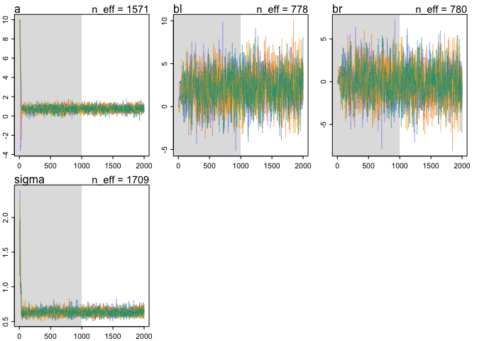

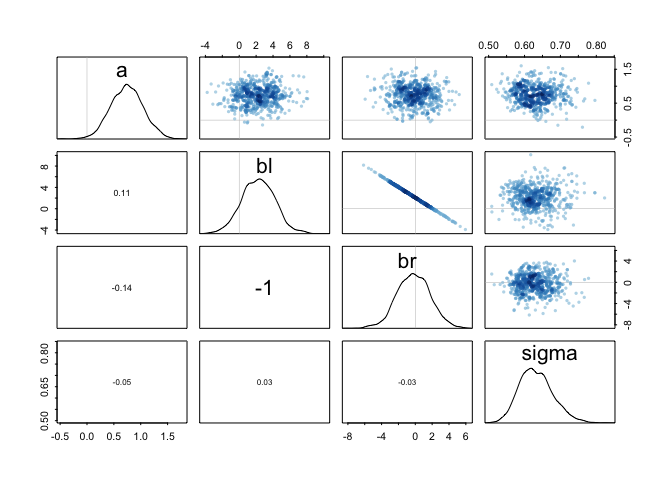

```r
plot(m5.8s) # this looks OK
pairs(m5.8s) # br and bl are totally correlated
```

```r
# as above, but make is so that br must be positive (makes sense, no?)
m5.8s2 <- map2stan(
  alist(
    height ~ dnorm( mu , sigma ) ,
    mu <- a + bl*leg_left + br*leg_right ,
    a ~ dnorm( 10 , 100 ) ,
    bl ~ dnorm( 2 , 10 ) ,
    br ~ dnorm( 2 , 10 ) & T[0,] ,
    sigma ~ dcauchy( 0 , 1 )
) ,
data=d, chains=4,
start=list(a=10,bl=0,br=0,sigma=1) )
```

[output not shown]

[output cut: 26 more lines]

[output not shown]

```
## Computing WAIC
## Constructing posterior predictions
```

```
## [ 400 / 4000 ]
[ 800 / 4000 ]
[ 1200 / 4000 ]
[ 1600 / 4000 ]
[ 2000 / 4000 ]
[ 2400 / 4000 ]
[ 2800 / 4000 ]
[ 3200 / 4000 ]
[ 3600 / 4000 ]
[ 4000 / 4000 ]
```